# Semestral Project: Analysis of Obesity Levels (Implementation and Evaluation of Advanced Methods in Machine Learning)

David Wagner, Viktor Klíma

04.05.2024

# Introduction

- **Classification Hypothesis:** We aim to classify individuals into two categories: those at risk of obesity and those not, by examining the influence of high-calorie food consumption frequency, the number of main meals, consumption of food between meals, alcohol consumption, age, and gender. This model seeks to understand how these dietary habits, demographic information, and personal behaviors correlate with the risk of obesity.

These hypotheses guide our exploration and analysis, contributing to a deeper understanding of the factors influencing obesity.

# Data Loading and Preprocessing

To initiate our analysis, the first step involves loading the dataset into our R environment. This dataset, stored as “ObesityDataSet.csv”, encapsulates vital information on obesity levels among individuals from specific Latin American countries. Our analysis begins by setting the working directory to where the dataset is located and subsequently loading the dataset into R for inspection and preprocessing.

```r
library(readr)
library(tidyverse)
library(lobstr)
library(dplyr)
library(ggplot2)
library(magrittr)
library(data.table)
library(caret)
library(MASS)
library(purrr)
library(GGally)
library(ggplot2)
library(gplots)
library(pROC)
library(kernlab)
library(stats)
library(e1071)


# Setting the working directory to where the dataset is located
# Uncomment the appropriate line below to match your directory structure
# setwd("C:/Users/dswag/Desktop/Zadania/OZNAL/Data")
setwd("C:/work/oznal/OZNAL_zadania/Data")

# Listing all files in the current working directory to verify the presence of our dataset
list.files()
```

```
## [1] "ObesityDataSet.csv"
```

```r
# Reading the dataset into R
raw_data <- read_csv("ObesityDataSet.csv", col_names = TRUE, num_threads = 4)

# Displaying the first few rows of the dataset to ensure it's loaded correctly
head(raw_data)
```

```
## # A tibble: 6 × 17
##   Gender   Age Height Weight family_history_with_overw…¹ FAVC   FCVC   NCP CAEC
##   <chr>  <dbl>  <dbl>  <dbl> <chr>                       <chr> <dbl> <dbl> <chr>
## 1 Female    21   1.62   64   yes                         no        2     3 Some…
## 2 Female    21   1.52   56   yes                         no        3     3 Some…
## 3 Male      23   1.8    77   yes                         no        2     3 Some…
## 4 Male      27   1.8    87   no                          no        3     3 Some…
## 5 Male      22   1.78   89.8 no                          no        2     1 Some…
## 6 Male      29   1.62   53   no                          yes       2     3 Some…
## # ℹ abbreviated name: ¹family_history_with_overweight
## # ℹ 8 more variables: SMOKE <chr>, CH2O <dbl>, SCC <chr>, FAF <dbl>, TUE <dbl>,
## #   CALC <chr>, MTRANS <chr>, Nobesity <chr>
```

```r
# Renaming columns in the dataset to make them more descriptive
names(raw_data)[names(raw_data) == "FAVC"] <- "FreqConsHighCalFood"
names(raw_data)[names(raw_data) == "FCVC"] <- "FreqConsVegs"
names(raw_data)[names(raw_data) == "NCP"] <- "NumMainMeals"
names(raw_data)[names(raw_data) == "CAEC"] <- "ConsFoodBetwMeals"
names(raw_data)[names(raw_data) == "CH2O"] <- "ConsWaterDaily"
names(raw_data)[names(raw_data) == "CALC"] <- "ConsAlc"
names(raw_data)[names(raw_data) == "SCC"] <- "CalsConsMon"
names(raw_data)[names(raw_data) == "FAF"] <- "PhysActFreq"
names(raw_data)[names(raw_data) == "TUE"] <- "TimeTechDev"
names(raw_data)[names(raw_data) == "MTRANS"] <- "Trans"

# Identifying missing values in dataset
sum(is.na(raw_data))
```

```
## [1] 0
```

```r
# Identifying missing values per column
colSums(is.na(raw_data))
```

```
##                         Gender                            Age
##                              0                              0
##                         Height                         Weight
##                              0                              0
## family_history_with_overweight            FreqConsHighCalFood
##                              0                              0
##                   FreqConsVegs                   NumMainMeals
##                              0                              0
##              ConsFoodBetwMeals                          SMOKE
##                              0                              0
##                 ConsWaterDaily                    CalsConsMon
##                              0                              0
##                    PhysActFreq                    TimeTechDev
##                              0                              0
##                        ConsAlc                          Trans
##                              0                              0
##                       Nobesity
##                              0
```

```r
# Function to identify outliers within one column (instead of 0.25 and 0.75 quantiles we used 0.15 and 0.85 to maintain a reasonable dataset size)
remove_outliers <- function(x) {
  # Ensure the column is numeric
  if(is.numeric(x)) {
    Q1 <- quantile(x, 0.15, na.rm = TRUE)
    Q3 <- quantile(x, 0.85, na.rm = TRUE)
    IQR <- Q3 - Q1
    lower_bound <- Q1 - 1.5 * IQR
    upper_bound <- Q3 + 1.5 * IQR
    x[x < lower_bound | x > upper_bound] <- NA  # Assign NA to outliers
  }
  x
}

# Apply the function to each column
cleaned_data <- raw_data %>% mutate(across(where(is.numeric), remove_outliers))

# If removing outliers introduced NAs, remove those rows
cleaned_data %<>% drop_na()
raw_data
```

```
## # A tibble: 2,111 × 17
##    Gender   Age Height Weight family_history_with_overweight FreqConsHighCalFood
##    <chr>  <dbl>  <dbl>  <dbl> <chr>                          <chr>
##  1 Female    21   1.62   64   yes                            no
##  2 Female    21   1.52   56   yes                            no
##  3 Male      23   1.8    77   yes                            no
##  4 Male      27   1.8    87   no                             no
##  5 Male      22   1.78   89.8 no                             no
##  6 Male      29   1.62   53   no                             yes
##  7 Female    23   1.5    55   yes                            yes
##  8 Male      22   1.64   53   no                             no
##  9 Male      24   1.78   64   yes                            yes
## 10 Male      22   1.72   68   yes                            yes
## # ℹ 2,101 more rows
## # ℹ 11 more variables: FreqConsVegs <dbl>, NumMainMeals <dbl>,
## #   ConsFoodBetwMeals <chr>, SMOKE <chr>, ConsWaterDaily <dbl>,
## #   CalsConsMon <chr>, PhysActFreq <dbl>, TimeTechDev <dbl>, ConsAlc <chr>,
## #   Trans <chr>, Nobesity <chr>
```

```r
cleaned_data
```

```
## # A tibble: 2,101 × 17
##    Gender   Age Height Weight family_history_with_overweight FreqConsHighCalFood
##    <chr>  <dbl>  <dbl>  <dbl> <chr>                          <chr>
##  1 Female    21   1.62   64   yes                            no
##  2 Female    21   1.52   56   yes                            no
##  3 Male      23   1.8    77   yes                            no
##  4 Male      27   1.8    87   no                             no
##  5 Male      22   1.78   89.8 no                             no
##  6 Male      29   1.62   53   no                             yes
##  7 Female    23   1.5    55   yes                            yes
##  8 Male      22   1.64   53   no                             no
##  9 Male      24   1.78   64   yes                            yes
## 10 Male      22   1.72   68   yes                            yes
## # ℹ 2,091 more rows
## # ℹ 11 more variables: FreqConsVegs <dbl>, NumMainMeals <dbl>,
## #   ConsFoodBetwMeals <chr>, SMOKE <chr>, ConsWaterDaily <dbl>,
## #   CalsConsMon <chr>, PhysActFreq <dbl>, TimeTechDev <dbl>, ConsAlc <chr>,
## #   Trans <chr>, Nobesity <chr>
```

```r
# Check for missing values again
sum(is.na(cleaned_data))
```

```
## [1] 0
```

```r
# Check data types of each column
str(cleaned_data)
```

```
## tibble [2,101 × 17] (S3: tbl_df/tbl/data.frame)
##  $ Gender                        : chr [1:2101] "Female" "Female" "Male" "Male" ...
##  $ Age                           : num [1:2101] 21 21 23 27 22 29 23 22 24 22 ...
##  $ Height                        : num [1:2101] 1.62 1.52 1.8 1.8 1.78 1.62 1.5 1.64 1.78 1.72 ...
##  $ Weight                        : num [1:2101] 64 56 77 87 89.8 53 55 53 64 68 ...
##  $ family_history_with_overweight: chr [1:2101] "yes" "yes" "yes" "no" ...
##  $ FreqConsHighCalFood           : chr [1:2101] "no" "no" "no" "no" ...
##  $ FreqConsVegs                  : num [1:2101] 2 3 2 3 2 2 3 2 3 2 ...
##  $ NumMainMeals                  : num [1:2101] 3 3 3 3 1 3 3 3 3 3 ...
##  $ ConsFoodBetwMeals             : chr [1:2101] "Sometimes" "Sometimes" "Sometimes" "Sometimes" ...
##  $ SMOKE                         : chr [1:2101] "no" "yes" "no" "no" ...
##  $ ConsWaterDaily                : num [1:2101] 2 3 2 2 2 2 2 2 2 2 ...
##  $ CalsConsMon                   : chr [1:2101] "no" "yes" "no" "no" ...
##  $ PhysActFreq                   : num [1:2101] 0 3 2 2 0 0 1 3 1 1 ...
##  $ TimeTechDev                   : num [1:2101] 1 0 1 0 0 0 0 0 1 1 ...
##  $ ConsAlc                       : chr [1:2101] "no" "Sometimes" "Frequently" "Frequently" ...
##  $ Trans                         : chr [1:2101] "Public_Transportation" "Public_Transportation" "Public_Transportation" "Walking" ...
##  $ Nobesity                      : chr [1:2101] "Normal_Weight" "Normal_Weight" "Normal_Weight" "Overweight_Level_I" ...
```

```r
# Convert all character columns to factors to represent categorical data
cleaned_data <- cleaned_data %>%
  mutate(across(where(is.character), as.factor))

# Check factorization of each column
str(cleaned_data)
```

```
## tibble [2,101 × 17] (S3: tbl_df/tbl/data.frame)
##  $ Gender                        : Factor w/ 2 levels "Female","Male": 1 1 2 2 2 2 1 2 2 2 ...
##  $ Age                           : num [1:2101] 21 21 23 27 22 29 23 22 24 22 ...
##  $ Height                        : num [1:2101] 1.62 1.52 1.8 1.8 1.78 1.62 1.5 1.64 1.78 1.72 ...
##  $ Weight                        : num [1:2101] 64 56 77 87 89.8 53 55 53 64 68 ...
##  $ family_history_with_overweight: Factor w/ 2 levels "no","yes": 2 2 2 1 1 1 2 1 2 2 ...
##  $ FreqConsHighCalFood           : Factor w/ 2 levels "no","yes": 1 1 1 1 1 2 2 1 2 2 ...
##  $ FreqConsVegs                  : num [1:2101] 2 3 2 3 2 2 3 2 3 2 ...
##  $ NumMainMeals                  : num [1:2101] 3 3 3 3 1 3 3 3 3 3 ...
##  $ ConsFoodBetwMeals             : Factor w/ 4 levels "Always","Frequently",..: 4 4 4 4 4 4 4 4 4 4 ...
##  $ SMOKE                         : Factor w/ 2 levels "no","yes": 1 2 1 1 1 1 1 1 1 1 ...
##  $ ConsWaterDaily                : num [1:2101] 2 3 2 2 2 2 2 2 2 2 ...
##  $ CalsConsMon                   : Factor w/ 2 levels "no","yes": 1 2 1 1 1 1 1 1 1 1 ...
##  $ PhysActFreq                   : num [1:2101] 0 3 2 2 0 0 1 3 1 1 ...
##  $ TimeTechDev                   : num [1:2101] 1 0 1 0 0 0 0 0 1 1 ...
##  $ ConsAlc                       : Factor w/ 4 levels "Always","Frequently",..: 3 4 2 2 4 4 4 4 2 3 ...
##  $ Trans                         : Factor w/ 5 levels "Automobile","Bike",..: 4 4 4 5 4 1 3 4 4 4 ...
##  $ Nobesity                      : Factor w/ 7 levels "Insufficient_Weight",..: 2 2 2 6 7 2 2 2 2 2 ...
```

```r
# Removing duplicate rows from the dataset, keeping only unique rows
cleaned_data <- cleaned_data %>% distinct()

cleaned_data
```

```
## # A tibble: 2,077 × 17
##    Gender   Age Height Weight family_history_with_overweight FreqConsHighCalFood
##    <fct>  <dbl>  <dbl>  <dbl> <fct>                          <fct>
##  1 Female    21   1.62   64   yes                            no
##  2 Female    21   1.52   56   yes                            no
##  3 Male      23   1.8    77   yes                            no
##  4 Male      27   1.8    87   no                             no
##  5 Male      22   1.78   89.8 no                             no
##  6 Male      29   1.62   53   no                             yes
##  7 Female    23   1.5    55   yes                            yes
##  8 Male      22   1.64   53   no                             no
##  9 Male      24   1.78   64   yes                            yes
## 10 Male      22   1.72   68   yes                            yes
## # ℹ 2,067 more rows
## # ℹ 11 more variables: FreqConsVegs <dbl>, NumMainMeals <dbl>,
## #   ConsFoodBetwMeals <fct>, SMOKE <fct>, ConsWaterDaily <dbl>,
## #   CalsConsMon <fct>, PhysActFreq <dbl>, TimeTechDev <dbl>, ConsAlc <fct>,
## #   Trans <fct>, Nobesity <fct>
```

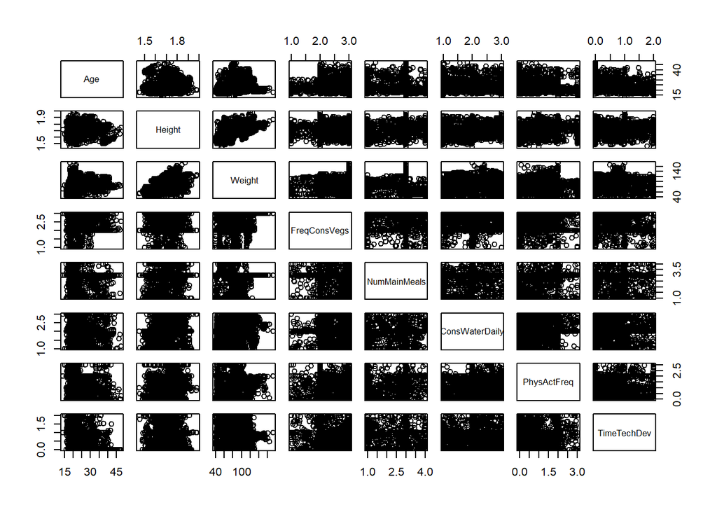

```r
# Select only the numeric columns for the pairs plot
numerical_data <- cleaned_data[sapply(cleaned_data, is.numeric) ]

# Use ggpairs to create the pairs plot, displaying both scatter plots and correlations
pairs(numerical_data)
```

```r
# Calculate correlation matrix for numerical columns
cor_matrix <- cor(numerical_data, use = "complete.obs")

cor_matrix
```

```
##                        Age      Height      Weight FreqConsVegs NumMainMeals
## Age             1.00000000 -0.03293759  0.21825694   0.01531373  -0.06620366
## Height         -0.03293759  1.00000000  0.45722858  -0.03964591   0.22793323
## Weight          0.21825694  0.45722858  1.00000000   0.21797138   0.09312056
## FreqConsVegs    0.01531373 -0.03964591  0.21797138   1.00000000   0.03578841
## NumMainMeals   -0.06620366  0.22793323  0.09312056   0.03578841   1.00000000
## ConsWaterDaily -0.05334106  0.22141038  0.20539028   0.07975121   0.07402446
## PhysActFreq    -0.16254693  0.29417826 -0.05575043   0.02084265   0.12498527
## TimeTechDev    -0.30022232  0.04223669 -0.08074858  -0.10568393   0.01683072
##                ConsWaterDaily PhysActFreq TimeTechDev
## Age               -0.05334106 -0.16254693 -0.30022232
## Height             0.22141038  0.29417826  0.04223669
## Weight             0.20539028 -0.05575043 -0.08074858
## FreqConsVegs       0.07975121  0.02084265 -0.10568393
## NumMainMeals       0.07402446  0.12498527  0.01683072
## ConsWaterDaily     1.00000000  0.16309029  0.02228917
## PhysActFreq        0.16309029  1.00000000  0.06012101
## TimeTechDev        0.02228917  0.06012101  1.00000000
```

```r
# Creating a new binary variable 'ObesityBinary' where 1 indicates Obesity (I, II, III) and 0 indicates otherwise
cleaned_data$ObesityBinary <- ifelse(cleaned_data$Nobesity %in% c("Obesity_Type_I", "Obesity_Type_II", "Obesity_Type_III"), 1, 0)

set.seed(123) # for reproducibility

# Calculate the size of the training set (80% of the dataset)
training_size <- floor(0.8 * nrow(cleaned_data))

# Sample indices for the training data
training_indices <- sample(seq_len(nrow(cleaned_data)), size = training_size)

# Split the data
train_data <- cleaned_data[training_indices, ]
test_data <- cleaned_data[-training_indices, ]
```

## Data distribution for a binary variable *ObesityBinary*

```r
# Print the number of cases and percentage distribution for training data
table_train <- table(train_data$ObesityBinary)
cat(sprintf("Training data - 'ObesityBinary' categories and percentages:\n Counts: %s, Percentages: %s\n",
            paste(names(table_train), table_train, sep=": ", collapse=", "),
            paste(names(table_train), round(prop.table(table_train) * 100, 2), sep=": ", collapse=", ") ))
```

```
## Training data - 'ObesityBinary' categories and percentages:
##  Counts: 0: 883, 1: 778, Percentages: 0: 53.16, 1: 46.84
```

```r
# Print the number of cases and percentage distribution for test data
table_test <- table(test_data$ObesityBinary)
cat(sprintf("Test data - 'ObesityBinary' categories and percentages:\n Counts: %s, Percentages: %s\n",
            paste(names(table_test), table_test, sep=": ", collapse=", "),
            paste(names(table_test), round(prop.table(table_test) * 100, 2), sep=": ", collapse=", ") ))
```

```
## Test data - 'ObesityBinary' categories and percentages:
##  Counts: 0: 223, 1: 193, Percentages: 0: 53.61, 1: 46.39
```

The output shows that the training and test datasets have a **similar distribution** of the ObesityBinary variable, where approximately **53%** of the cases belong to category **0** and about **47%** to category **1**. This near-even distribution indicates that the datasets are **well-balanced** between the two categories. Given this balance, there is **no need** for adjustments regarding class balancing techniques such as oversampling or undersampling, which are often used when one class significantly outnumbers the other. This **consistency** in distribution across both datasets ensures that any model trained on this data is **less** likely to be biased towards a particular class, providing a **fair** representation for both categories.

# Hypothesis

**Null Hypothesis (H0):** There is no significant relationship between the risk of obesity and the independent variables of frequency of consuming high-calorie food, number of main meals, consumption of food between meals, alcohol consumption, age, and gender. These variables do not significantly contribute to predicting whether an individual is at risk of obesity or not.

**Alternative Hypothesis (H1):** There is a significant relationship between the risk of obesity and the independent variables of frequency of consuming high-calorie food, number of main meals, consumption of food between meals, alcohol consumption, age, and gender. These factors collectively serve as significant predictors in classifying individuals into categories indicating their risk of obesity.

We aim to classify individuals into binary obesity levels (1 if Obesity I/II/III, otherwise 0) by analyzing their eating habits, physical condition, and demographic information.

# Selection of classification methods

We chose the following classification methods based on their characteristics because:

- **LDA** works efficiently with linear separability and normal distribution assumptions, ideal for balanced classes to reduce complexity and improve speed.
- **SVM** excels at creating optimal hyperplanes, especially beneficial in balanced datasets where overfitting the majority class is less of a concern, allowing for accurate and robust classification.
- **Naive Bayes** is effective in high-dimensional spaces and when predictors are independent, requiring less data to estimate parameters, making it scalable and fast.

These models leverage the balanced class distribution to perform optimally, avoiding biases toward a dominant class and enhancing overall model accuracy and generalizability.

# LDA

The Linear Discriminant Analysis (LDA) model for predicting obesity status based on dietary habits, alcohol consumption, age, and gender demonstrates a good performance in classification.

```r
# Creating LDA model
lda_model <- lda(ObesityBinary ~ FreqConsHighCalFood + NumMainMeals + ConsFoodBetwMeals + ConsAlc + Age + Gender, data = train_data)

# Printing model results
print(summary(lda_model))
```

```
##         Length Class  Mode
## prior    2     -none- numeric
## counts   2     -none- numeric
## means   20     -none- numeric
## scaling 10     -none- numeric
## lev      2     -none- character
## svd      1     -none- numeric
## N        1     -none- numeric
## call     3     -none- call
## terms    3     terms  call
## xlevels  4     -none- list
```

```r
# Predicting on the test set, obtaining probabilities
lda_probabilities <- predict(lda_model, newdata = test_data, type = "response")$posterior[,2]

# Setting the threshold
threshold <- 0.55  # This threshold means that probabilities above 0.6 will be classified as positive

# Applying threshold to predictions
predicted_classes <- ifelse(lda_probabilities > threshold, 1, 0)

# Creating and printing confusion matrix
lda_conf_matrix <- table(Predicted = predicted_classes, Actual = test_data$ObesityBinary)
print(lda_conf_matrix)
```

```
##          Actual
## Predicted   0   1
##         0 149  45
##         1  74 148
```

```r
# Calculating accuracy and other metrics
accuracy <- sum(predicted_classes == test_data$ObesityBinary) / nrow(test_data)
print(paste("Accuracy:", accuracy))
```

```
## [1] "Accuracy: 0.713942307692308"
```

```r
# Calculating additional metrics using the caret package
library(caret)
confusionMatrix(lda_conf_matrix)
```

```
## Confusion Matrix and Statistics
##
##          Actual
## Predicted   0   1
##         0 149  45
##         1  74 148
##
##                Accuracy : 0.7139
##                  95% CI : (0.6679, 0.7569)
##     No Information Rate : 0.5361
##     P-Value [Acc > NIR] : 8.516e-14
##
##                   Kappa : 0.4306
##
##  Mcnemar's Test P-Value : 0.01027
##
##             Sensitivity : 0.6682
##             Specificity : 0.7668
##          Pos Pred Value : 0.7680
##          Neg Pred Value : 0.6667
##              Prevalence : 0.5361
##          Detection Rate : 0.3582
##    Detection Prevalence : 0.4663
##       Balanced Accuracy : 0.7175
##
##        'Positive' Class : 0
##
```

In summary, the LDA model performs well and can be a useful tool for predicting obesity status in the given context, although there is some room for improvement, especially in reducing false negatives.

# SVM

The Support Vector Machine (SVM) with a radial kernel is applied to classify a binary variable, ObesityBinary, based on several features such as frequency of consuming high-calorie food, number of main meals, consumption of food between meals, alcohol consumption, age, and gender.

```r
# Creating an SVM model with a radial kernel
svm_model <- svm(ObesityBinary ~ FreqConsHighCalFood + NumMainMeals + ConsFoodBetwMeals + ConsAlc + Age + Gender,
                 data = train_data,
                 type = 'C-classification',
                 kernel = 'radial',
                 probability = TRUE)  # Enabling probabilities

# Printing model results
print(summary(svm_model))
```

```
##
## Call:
## svm(formula = ObesityBinary ~ FreqConsHighCalFood + NumMainMeals +
##     ConsFoodBetwMeals + ConsAlc + Age + Gender, data = train_data,
##     type = "C-classification", kernel = "radial", probability = TRUE)
##
##
## Parameters:
##    SVM-Type:  C-classification
##  SVM-Kernel:  radial
##        cost:  1
##
## Number of Support Vectors:  957
##
##  ( 480 477 )
##
##
## Number of Classes:  2
##
## Levels:
##  0 1
```

```r
# Predicting on the test set, obtaining probabilities
svm_probabilities <- predict(svm_model, newdata = test_data, probability = TRUE)
svm_probabilities <- attr(svm_probabilities, "probabilities")[,2]

# Setting the threshold
threshold <- 0.55

# Applying the threshold to predictions
svm_predicted_classes <- ifelse(svm_probabilities > threshold, 1, 0)

# Creating and printing confusion matrix
svm_conf_matrix <- table(Predicted = svm_predicted_classes, Actual = test_data$ObesityBinary)
print(svm_conf_matrix)
```

```
##          Actual
## Predicted   0   1
##         0 152  27
##         1  71 166
```

```r
# Calculating accuracy
svm_accuracy <- sum(svm_predicted_classes == test_data$ObesityBinary) / nrow(test_data)
print(paste("Accuracy:", svm_accuracy))
```

```
## [1] "Accuracy: 0.764423076923077"
```

```r
# Calculating additional metrics using the caret package
library(caret)
svm_confusionMatrix <- confusionMatrix(svm_conf_matrix)
print(svm_confusionMatrix)
```

```
## Confusion Matrix and Statistics
##
##          Actual
## Predicted   0   1
##         0 152  27
##         1  71 166
##
##                Accuracy : 0.7644
##                  95% CI : (0.7206, 0.8044)
##     No Information Rate : 0.5361
##     P-Value [Acc > NIR] : < 2.2e-16
##
##                   Kappa : 0.5335
##
##  Mcnemar's Test P-Value : 1.401e-05
##
##             Sensitivity : 0.6816
##             Specificity : 0.8601
##          Pos Pred Value : 0.8492
##          Neg Pred Value : 0.7004
##              Prevalence : 0.5361
##          Detection Rate : 0.3654
##    Detection Prevalence : 0.4303
##       Balanced Accuracy : 0.7709
##
##        'Positive' Class : 0
##
```

Overall, the SVM model with a radial kernel showed a fairly high level of accuracy, a good balance between sensitivity and specificity, and strong predictive values, suggesting it performs well for this particular classification task. The radial basis function (RBF) kernel, was chosen for the SVM model due to its flexibility in handling data where the boundary between classes is not linear.

# Naive Bayse

The Naive Bayes model was created to predict a binary target variable, ObesityBinary, based on various predictors including the frequency of consuming high-calorie food, the number of main meals, consumption of food between meals, alcohol consumption, age, and gender.

```r
# Creating Naive Bayes model
nb_model <- naiveBayes(ObesityBinary ~ FreqConsHighCalFood + NumMainMeals + ConsFoodBetwMeals + ConsAlc + Age + Gender,
                       data = train_data)

# Printing model results
print(summary(nb_model))
```

```
##           Length Class  Mode
## apriori   2      table  numeric
## tables    6      -none- list
## levels    2      -none- character
## isnumeric 6      -none- logical
## call      4      -none- call
```

```r
# Predicting on the test set, obtaining probabilities
nb_probabilities <- predict(nb_model, newdata = test_data, type = "raw")[,2]

# Setting the threshold
threshold <- 0.65

# Applying the threshold to predictions
nb_predicted_classes <- ifelse(nb_probabilities > threshold, 1, 0)

# Creating and printing confusion matrix
nb_conf_matrix <- table(Predicted = nb_predicted_classes, Actual = test_data$ObesityBinary)
print(nb_conf_matrix)
```

```
##          Actual
## Predicted   0   1
##         0 166  66
##         1  57 127
```

```r
# Calculating accuracy
nb_accuracy <- sum(nb_predicted_classes == test_data$ObesityBinary) / nrow(test_data)
print(paste("Accuracy:", nb_accuracy))
```

```
## [1] "Accuracy: 0.704326923076923"
```

```r
# Calculating additional metrics using the caret package
nb_confusionMatrix <- confusionMatrix(nb_conf_matrix)
print(nb_confusionMatrix)
```

```
## Confusion Matrix and Statistics
##
##          Actual
## Predicted   0   1
##         0 166  66
##         1  57 127
##
##                Accuracy : 0.7043
##                  95% CI : (0.6579, 0.7478)
##     No Information Rate : 0.5361
##     P-Value [Acc > NIR] : 1.741e-12
##
##                   Kappa : 0.4037
##
##  Mcnemar's Test P-Value : 0.4707
##
##             Sensitivity : 0.7444
##             Specificity : 0.6580
##          Pos Pred Value : 0.7155
##          Neg Pred Value : 0.6902
##              Prevalence : 0.5361
##          Detection Rate : 0.3990
##    Detection Prevalence : 0.5577
##       Balanced Accuracy : 0.7012
##
##        'Positive' Class : 0
##
```

The Naive Bayes classifier performs reasonably well, with an accuracy significantly higher than the no information rate. The balance between sensitivity and specificity suggests the model is fair at discriminating both classes. However, further improvements may be necessary to increase its predictive performance.

# Model performance parameters

```r
# Calculate metrics using confusionMatrix and store the results
lda_cm <- confusionMatrix(lda_conf_matrix)
svm_cm <- confusionMatrix(svm_conf_matrix)
nb_cm <- confusionMatrix(nb_conf_matrix)

# Create summary table
model_summary <- data.frame(
  Model = c("LDA", "SVM", "Naive Bayes"),
  Accuracy = c(lda_cm$overall['Accuracy'], svm_cm$overall['Accuracy'], nb_cm$overall['Accuracy']),
  Sensitivity = c(lda_cm$byClass['Sensitivity'], svm_cm$byClass['Sensitivity'], nb_cm$byClass['Sensitivity']),
  Specificity = c(lda_cm$byClass['Specificity'], svm_cm$byClass['Specificity'], nb_cm$byClass['Specificity']),
  F1_Score = c(lda_cm$byClass['F1'], svm_cm$byClass['F1'], nb_cm$byClass['F1'])
)

# Calculate AUC for each model
lda_auc <- roc(response = test_data$ObesityBinary, predictor = lda_probabilities)$auc
svm_auc <- roc(response = test_data$ObesityBinary, predictor = svm_probabilities)$auc
nb_auc <- roc(response = test_data$ObesityBinary, predictor = nb_probabilities)$auc
# Add AUC values to the summary table
model_summary$AUC <- c(lda_auc, svm_auc, nb_auc)

# Print summary table
print(model_summary)
```

```
##         Model  Accuracy Sensitivity Specificity  F1_Score       AUC
## 1         LDA 0.7139423   0.6681614   0.7668394 0.7146283 0.7618904
## 2         SVM 0.7644231   0.6816143   0.8601036 0.7562189 0.8430493
## 3 Naive Bayes 0.7043269   0.7443946   0.6580311 0.7296703 0.7742048
```

```r
# ROC analysis for each model
lda_roc <- roc(test_data$ObesityBinary, lda_probabilities)
svm_roc <- roc(test_data$ObesityBinary, svm_probabilities)
nb_roc <- roc(test_data$ObesityBinary, nb_probabilities)
```

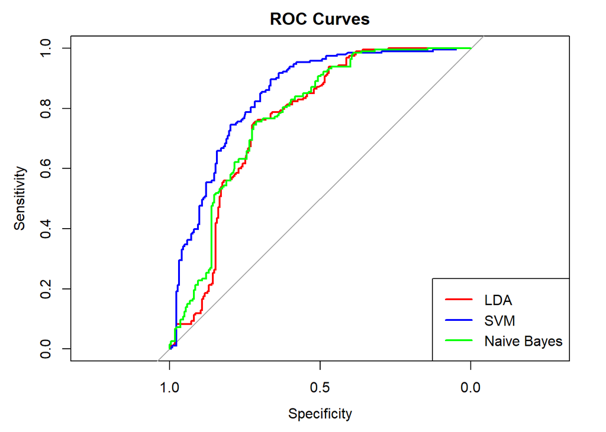

```r
# Plot ROC curves
plot(lda_roc, main="ROC Curves", col="red")
lines(svm_roc, col="blue")
lines(nb_roc, col="green")
legend("bottomright", legend=c("LDA", "SVM", "Naive Bayes"), col=c("red", "blue", "green"), lwd=2)
```

### Accuracy

This metric reflects the overall correctness of the model, representing the ratio of correct predictions to total predictions.

- LDA: 71.39%
- SVM: 76.44%
- Naive Bayes: 70.43%

### Sensitivity (Recall or True Positive Rate)

Indicates how well the model identifies actual positives.

- LDA: 66.82%
- SVM: 68.16%
- Naive Bayes: 74.44%

### Specificity (True Negative Rate)

Shows how well the model identifies actual negatives.

- LDA: 76.68%
- SVM: 86.01%
- Naive Bayes: 65.80%

### F1 Score

The harmonic mean of precision and sensitivity, giving a balance of both in cases where one might be more important than the other.

- LDA: 71.46%
- SVM: 75.62%
- Naive Bayes: 72.97%

### AUC (Area Under the ROC Curve)

Reflects the model’s ability to discriminate between the positive and negative classes. The closer to 1, the better the model is at predicting positive classes as positive and negative classes as negative.

- LDA: 76.19%
- SVM: 84.30%
- Naive Bayes: 77.42%

From these metrics we can tell that:

- **SVM** is the **best** performer in terms of accuracy, specificity, F1 score, and AUC, which suggests it’s the **most balanced** model overall among the three.
- **Naive Bayes** has the **highest** sensitivity, meaning it is the **best at identifying positive cases**, but it **lags** in specificity, indicating it may **misclassify** more negative cases as positive.
- **LDA** offers **moderate** performance across all metrics, with no extremes in sensitivity or specificity, suggesting a **balanced** but **less** accurate prediction compared to SVM.

# Conclusion

These metrics collectively indicate that the models, utilizing these specific predictors, are effective at classifying individuals based on their risk of obesity, thereby providing substantial evidence against the Null Hypothesis (H0) and in favor of the Alternative Hypothesis (H1).

### Tuning

We recognized that Linear Discriminant Analysis (LDA) lacks tunable hyperparameters because it operates based on fixed assumptions like normal distribution and equal covariance across classes. Due to this, traditional hyperparameter tuning is not applicable for LDA.

Instead, we focused on adjusting the decision threshold to optimize the all models. This method allowed us to control the sensitivity and specificity of the models by changing the probability cutoff for classifying observations. By fine-tuning this threshold, we tailored the performance of the models to better meet our specific evaluation criteria, effectively optimizing our model’s effectiveness within the constraints of our project.

### Formula

We chose to use the same formula (ObesityBinary ~ FreqConsHighCalFood + NumMainMeals + ConsFoodBetwMeals + ConsAlc + Age + Gender) for every model to ensure consistency in variable selection and to directly compare model performance. By applying the same predictors across SVM, LDA, and Naive Bayes, we isolated the effect of the modeling techniques on the outcomes. This approach allowed us to attribute any performance differences solely to the models’ inherent capabilities, rather than variable selection, enabling an effective evaluation of each model’s strengths and weaknesses under identical conditions.

### Predictor combinations

In our analysis, we experimented with various combinations of predictors from a total of 17 available parameters. Through iterative testing, we assessed the impact of different predictor sets on model performance. We ultimately converged on the combination of FreqConsHighCalFood, NumMainMeals, ConsFoodBetwMeals, ConsAlc, Age, and Gender as the most effective. This specific set of predictors provided the best balance of model accuracy and interpretability, yielding the most consistent and insightful results across different models. Given our limited set of 17 parameters, our selection was also influenced by the need to avoid overfitting while capturing the most significant predictors for our target variable.

### Comparison with Project 1

Overall, the new models provide a more accurate and balanced approach to predicting obesity risk compared to the original model, with SVM showing the strongest performance enhancements across the board.